# R Notebook

# Multivariate Plots Section

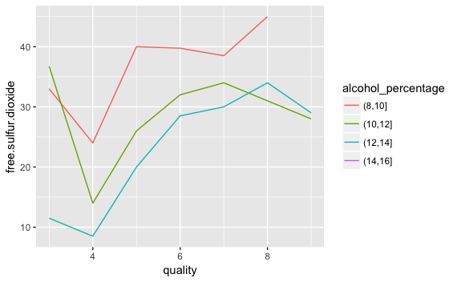

we can see that that initial quality of wine increses by decresing the free sulphur dioxide till quality 4.After this we can see that by incresing quality of wine increses by incresing the free sulphur dioxide then again by decresing by free sulphur dioxide .Quality value increses.

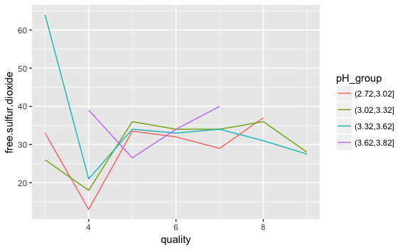

We can see that that initial quality of wine increses by decresing the free sulphur dioxide till quality 4.After this we can see that by incresing quality of wine increses by incresing the free sulphur dioxide then again by decresing by free sulphur dioxide .Quality value increses.

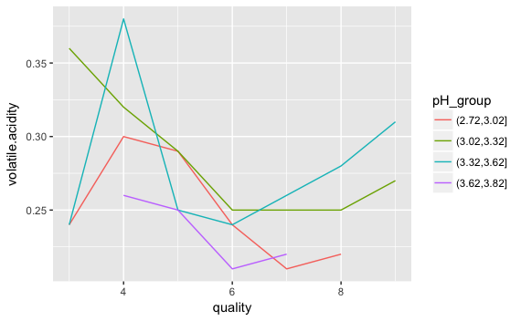

We can see that that initial quality of wine increses by incresing the volatile acidity till quality 4.Except pH group (3.02,3.32).After this we can see that increses quality of wine increses by decresing volatile acidity then again by incresing volatile acidity ,Quality value increses. ### Quality vs. fixed sulphur dioxide and alcohol

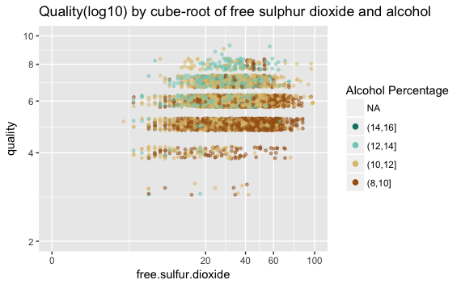

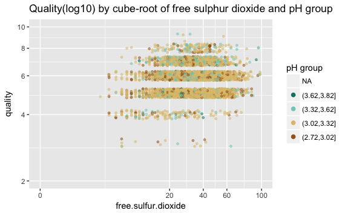

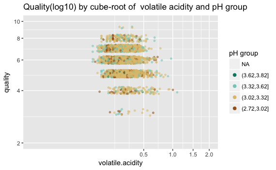

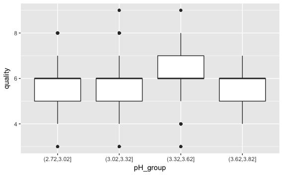